# Week 7 R example

6회차에서 썻던 데이터 가져와서 하자!

```r
library(data.table)
library(tidyverse)
data = fread('2017-18_NBA_salary.csv')
```

데이터 확인

```r
data %>% dim
```

```
## [1] 485  28
```

```r
data %>% glimpse
```

```
## Rows: 485
## Columns: 28
## $ Player          <chr> "Zhou Qi", "Zaza Pachulia", "Zach Randolph", "Zach ...
## $ Salary          <int> 815615, 3477600, 12307692, 3202217, 3057240, 131261...
## $ NBA_Country     <chr> "China", "Georgia", "USA", "USA", "USA", "USA", "US...
## $ NBA_DraftNumber <int> 43, 42, 19, 13, 10, 62, 62, 62, 23, 35, 62, 6, 40, ...
## $ Age             <int> 22, 33, 36, 22, 20, 24, 30, 23, 30, 23, 27, 24, 27,...
## $ Tm              <chr> "HOU", "GSW", "SAC", "CHI", "POR", "DAL", "BOS", "M...
## $ G               <int> 16, 66, 59, 24, 62, 79, 2, 5, 70, 45, 42, 70, 77, 6...
## $ MP              <int> 87, 937, 1508, 656, 979, 2238, 7, 118, 2200, 430, 4...
## $ PER             <dbl> 0.6, 16.8, 17.3, 14.6, 8.2, 11.5, -4.9, 0.9, 11.1, ...
## $ `TS%`           <dbl> 0.303, 0.608, 0.529, 0.499, 0.487, 0.543, 0.000, 0....
## $ `3PAr`          <dbl> 0.593, 0.004, 0.193, 0.346, 0.387, 0.489, 0.667, 0....
## $ FTr             <dbl> 0.370, 0.337, 0.140, 0.301, 0.146, 0.141, 0.000, 0....
## $ `ORB%`          <dbl> 6.5, 11.0, 7.0, 1.4, 4.9, 1.3, 15.9, 0.0, 5.0, 13.6...
## $ `DRB%`          <dbl> 16.8, 25.0, 23.8, 14.4, 18.3, 11.3, 15.4, 5.0, 14.0...
## $ `TRB%`          <dbl> 11.7, 18.5, 15.0, 7.7, 11.7, 6.1, 15.7, 2.5, 9.5, 1...
## $ `AST%`          <dbl> 1.5, 15.4, 14.9, 18.6, 7.3, 13.3, 0.0, 23.2, 9.7, 1...
## $ `STL%`          <dbl> 1.1, 1.9, 1.4, 1.8, 0.8, 1.4, 7.2, 2.6, 0.9, 1.8, 1...
## $ `BLK%`          <dbl> 6.8, 1.3, 0.6, 0.5, 2.5, 0.3, 0.0, 2.4, 1.4, 2.8, 4...
## $ `TOV%`          <dbl> 18.2, 19.3, 12.5, 9.7, 15.6, 9.1, 0.0, 19.3, 12.0, ...
## $ `USG%`          <dbl> 19.5, 17.2, 27.6, 29.5, 15.5, 17.0, 19.2, 21.7, 14....
## $ OWS             <dbl> -0.4, 1.7, 0.3, -0.1, -0.4, 1.6, -0.1, -0.5, 2.0, 0...
## $ DWS             <dbl> 0.1, 1.4, 1.1, 0.5, 1.2, 1.6, 0.0, 0.1, 1.0, 0.6, 0...
## $ WS              <dbl> -0.2, 3.1, 1.4, 0.4, 0.8, 3.1, 0.0, -0.4, 3.1, 1.4,...
## $ `WS/48`         <dbl> -0.121, 0.160, 0.046, 0.027, 0.038, 0.067, -0.251, ...
## $ OBPM            <dbl> -10.6, -0.6, -0.6, -0.7, -3.7, -0.4, -12.6, -8.7, -...
## $ DBPM            <dbl> 0.5, 1.3, -1.3, -2.0, 0.9, -0.5, -0.7, -1.9, -0.6, ...
## $ BPM             <dbl> -10.1, 0.8, -1.9, -2.6, -2.9, -0.9, -13.3, -10.6, -...
## $ VORP            <dbl> -0.2, 0.7, 0.0, -0.1, -0.2, 0.6, 0.0, -0.3, 0.5, 0....
```

기본적인 전처리. 변수는 다중공선성의 발생을 위해 많이 가져온다. 또한 관련있는 변수들도 다 가져온다.

```r
data <- data[complete.cases(data), ] # 결측치 제거
data <- data[-c(223:224), ] #겹치는 선수 삭제
data$Player <- NULL
data$Tm <- NULL
data$NBA_Country <- NULL
data$Salary = data$Salary^0.22

data = data %>% select('Salary', 'NBA_DraftNumber', 'Age', 'MP', 'PER',
                       `TS%`, `DRB%`, VORP, G, OBPM, DBPM, BPM, OWS, DWS, WS, `AST%`, `STL%`)
data %>% dim
```

```
## [1] 481  17
```

```r
salary.reg <- lm(Salary ~ ., data = data)
summary(salary.reg)
```

```
##
## Call:
## lm(formula = Salary ~ ., data = data)
##
## Residuals:
##      Min       1Q   Median       3Q      Max
## -18.9544  -3.4684  -0.0954   3.4870  17.1111
##
## Coefficients:
##                   Estimate Std. Error t value Pr(>|t|)
## (Intercept)      9.7419408  3.3711747   2.890  0.00404 **
## NBA_DraftNumber -0.1165441  0.0132421  -8.801  < 2e-16 ***
## Age              0.6056871  0.0607667   9.967  < 2e-16 ***
## MP               0.0059510  0.0009751   6.103  2.2e-09 ***
## PER             -0.1401010  0.1039947  -1.347  0.17858
## `TS%`            4.4526240  4.1664777   1.069  0.28577
## `DRB%`           0.1611449  0.0628951   2.562  0.01072 *
## VORP             0.1470256  0.6417913   0.229  0.81890
## G               -0.0805767  0.0262561  -3.069  0.00227 **
## OBPM            -1.5081608  5.0167530  -0.301  0.76384
## DBPM            -1.5215617  5.0078586  -0.304  0.76139
## BPM              1.6711061  5.0094837   0.334  0.73884
## OWS             -1.7356016  4.8495935  -0.358  0.72059
## DWS             -2.0844077  4.8609972  -0.429  0.66827
## WS               1.9601738  4.8624836   0.403  0.68704
## `AST%`           0.0173818  0.0338968   0.513  0.60834
## `STL%`          -0.0544408  0.3491739  -0.156  0.87617
## ---
## Signif. codes:  0 '***' 0.001 '**' 0.01 '*' 0.05 '.' 0.1 ' ' 1
##
## Residual standard error: 5.526 on 464 degrees of freedom
## Multiple R-squared:  0.5608, Adjusted R-squared:  0.5457
## F-statistic: 37.03 on 16 and 464 DF,  p-value: < 2.2e-16
```

다중공선성이 상당히 의심되기 때문에, 상관계수 플랏을 통해 확인해보자.

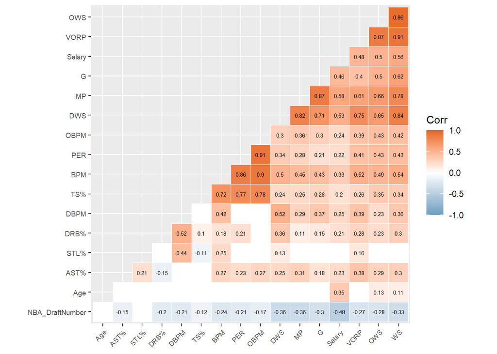

```r
#상관계수 플랏
library(ggcorrplot)
corr <- cor(data) # 상관계수 행렬
p_mat <- cor_pmat(data) # 상관계수 p-value 행렬
ggcorrplot(corr, hc.order = T, type = "lower",
           outline.color = "white", ggtheme = ggplot2::theme_gray(),
           colors = c("#6D9EC1", "white", "#E46726"), lab = T, p.mat = p_mat,
           insig = "blank", lab_size = 2, tl.cex = 7)
```

변수들이 매우 다중공선성이 심각해보인다.

## 1. 변수 선택법

변수선택법을 통해 최적의 회귀식을 찾아보자

### Best Subset Selection

```r
library(leaps)
best_subset = regsubsets(Salary ~ ., data = data, nvmax = 13)
bs = best_subset %>% summary
bs
```

```
## Subset selection object
## Call: regsubsets.formula(Salary ~ ., data = data, nvmax = 13)
## 16 Variables  (and intercept)
##                 Forced in Forced out
## NBA_DraftNumber     FALSE      FALSE
## Age                 FALSE      FALSE
## MP                  FALSE      FALSE
## PER                 FALSE      FALSE
## `TS%`               FALSE      FALSE
## `DRB%`              FALSE      FALSE
## VORP                FALSE      FALSE
## G                   FALSE      FALSE
## OBPM                FALSE      FALSE
## DBPM                FALSE      FALSE
## BPM                 FALSE      FALSE
## OWS                 FALSE      FALSE
## DWS                 FALSE      FALSE
## WS                  FALSE      FALSE
## `AST%`              FALSE      FALSE
## `STL%`              FALSE      FALSE
## 1 subsets of each size up to 13
## Selection Algorithm: exhaustive
##           NBA_DraftNumber Age MP  PER `TS%` `DRB%` VORP G   OBPM DBPM BPM OWS
## 1  ( 1 )  " "             " " "*" " " " "   " "    " "  " " " "  " "  " " " "
## 2  ( 1 )  " "             "*" "*" " " " "   " "    " "  " " " "  " "  " " " "
## 3  ( 1 )  "*"             "*" "*" " " " "   " "    " "  " " " "  " "  " " " "
## 4  ( 1 )  "*"             "*" "*" " " " "   " "    "*"  " " " "  " "  " " " "
## 5  ( 1 )  "*"             "*" "*" " " " "   "*"    " "  "*" " "  " "  " " " "
## 6  ( 1 )  "*"             "*" "*" " " " "   "*"    "*"  "*" " "  " "  " " " "
## 7  ( 1 )  "*"             "*" "*" " " " "   "*"    " "  "*" " "  "*"  " " "*"
## 8  ( 1 )  "*"             "*" "*" "*" " "   "*"    " "  "*" " "  " "  "*" "*"
## 9  ( 1 )  "*"             "*" "*" "*" "*"   "*"    " "  "*" " "  " "  "*" "*"
## 10  ( 1 ) "*"             "*" "*" "*" "*"   "*"    " "  "*" " "  " "  "*" "*"
## 11  ( 1 ) "*"             "*" "*" "*" "*"   "*"    " "  "*" " "  " "  "*" " "
## 12  ( 1 ) "*"             "*" "*" "*" "*"   "*"    " "  "*" " "  " "  "*" "*"
## 13  ( 1 ) "*"             "*" "*" "*" "*"   "*"    "*"  "*" " "  " "  "*" "*"
##           DWS WS  `AST%` `STL%`
## 1  ( 1 )  " " " " " "    " "
## 2  ( 1 )  " " " " " "    " "
## 3  ( 1 )  " " " " " "    " "
## 4  ( 1 )  " " " " " "    " "
## 5  ( 1 )  " " " " " "    " "
## 6  ( 1 )  " " " " " "    " "
## 7  ( 1 )  " " " " " "    " "
## 8  ( 1 )  " " " " " "    " "
## 9  ( 1 )  " " " " " "    " "
## 10  ( 1 ) " " " " "*"    " "
## 11  ( 1 ) "*" "*" "*"    " "
## 12  ( 1 ) "*" "*" "*"    " "
## 13  ( 1 ) "*" "*" "*"    " "
```

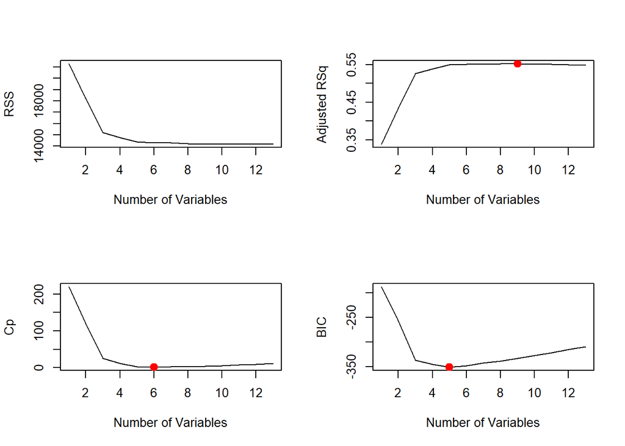

```r
par(mfrow = c(2, 2))
plot(bs$rss, xlab = "Number of Variables", ylab = "RSS", type = "l")
plot(bs$adjr2, xlab = "Number of Variables", ylab = "Adjusted RSq", type = "l")
l = which.max(bs$adjr2)
points(l, bs$adjr2[l], col = "red", cex = 2, pch = 20)
plot(bs$cp, xlab = "Number of Variables", ylab = "Cp", type = 'l')
l = which.min(bs$cp)
points(l, bs$cp[l], col = "red", cex = 2, pch = 20)
plot(bs$bic, xlab = "Number of Variables", ylab = "BIC", type = 'l')
l = which.min(bs$bic)
points(l, bs$bic[l], col = "red", cex = 2, pch = 20)
```

```r
par(mfrow = c(1, 1))
```

변수가 이렇게 기준이 다르다. 그러면 그냥 변수 적은게 좋다고 생각한다!

```r
coef(best_subset, 5)
```

```
##     (Intercept) NBA_DraftNumber             Age              MP          `DRB%`
##     8.925461291    -0.115949249     0.631144863     0.006450267     0.157200536
##               G
##    -0.075904237
```

```r
best_lm_fit = lm(Salary ~ NBA_DraftNumber + Age + MP + `DRB%` + G, data = data)
summary(best_lm_fit)
```

```
##
## Call:
## lm(formula = Salary ~ NBA_DraftNumber + Age + MP + `DRB%` + G,
##     data = data)
##
## Residuals:
##      Min       1Q   Median       3Q      Max
## -19.3521  -3.5123   0.0707   3.6013  15.9676
##
## Coefficients:
##                   Estimate Std. Error t value Pr(>|t|)
## (Intercept)      8.9254613  1.8094178   4.933 1.12e-06 ***
## NBA_DraftNumber -0.1159492  0.0130060  -8.915  < 2e-16 ***
## Age              0.6311449  0.0590469  10.689  < 2e-16 ***
## MP               0.0064503  0.0006529   9.879  < 2e-16 ***
## `DRB%`           0.1572005  0.0382059   4.115 4.57e-05 ***
## G               -0.0759042  0.0209923  -3.616 0.000331 ***
## ---
## Signif. codes:  0 '***' 0.001 '**' 0.01 '*' 0.05 '.' 0.1 ' ' 1
##
## Residual standard error: 5.506 on 475 degrees of freedom
## Multiple R-squared:  0.5537, Adjusted R-squared:  0.549
## F-statistic: 117.9 on 5 and 475 DF,  p-value: < 2.2e-16
```

### Forward Selection

```r
forward_selection = regsubsets(Salary ~ ., data = data, nvmax = 13, method = "forward")
summary(forward_selection)
```

```
## Subset selection object
## Call: regsubsets.formula(Salary ~ ., data = data, nvmax = 13, method = "forward")
## 16 Variables  (and intercept)
##                 Forced in Forced out
## NBA_DraftNumber     FALSE      FALSE
## Age                 FALSE      FALSE
## MP                  FALSE      FALSE
## PER                 FALSE      FALSE
## `TS%`               FALSE      FALSE
## `DRB%`              FALSE      FALSE
## VORP                FALSE      FALSE
## G                   FALSE      FALSE
## OBPM                FALSE      FALSE
## DBPM                FALSE      FALSE
## BPM                 FALSE      FALSE
## OWS                 FALSE      FALSE
## DWS                 FALSE      FALSE
## WS                  FALSE      FALSE
## `AST%`              FALSE      FALSE
## `STL%`              FALSE      FALSE
## 1 subsets of each size up to 13
## Selection Algorithm: forward
##           NBA_DraftNumber Age MP  PER `TS%` `DRB%` VORP G   OBPM DBPM BPM OWS
## 1  ( 1 )  " "             " " "*" " " " "   " "    " "  " " " "  " "  " " " "
## 2  ( 1 )  " "             "*" "*" " " " "   " "    " "  " " " "  " "  " " " "
## 3  ( 1 )  "*"             "*" "*" " " " "   " "    " "  " " " "  " "  " " " "
## 4  ( 1 )  "*"             "*" "*" " " " "   " "    "*"  " " " "  " "  " " " "
## 5  ( 1 )  "*"             "*" "*" " " " "   "*"    "*"  " " " "  " "  " " " "
## 6  ( 1 )  "*"             "*" "*" " " " "   "*"    "*"  "*" " "  " "  " " " "
## 7  ( 1 )  "*"             "*" "*" " " "*"   "*"    "*"  "*" " "  " "  " " " "
## 8  ( 1 )  "*"             "*" "*" "*" "*"   "*"    "*"  "*" " "  " "  " " " "
## 9  ( 1 )  "*"             "*" "*" "*" "*"   "*"    "*"  "*" " "  " "  "*" " "
## 10  ( 1 ) "*"             "*" "*" "*" "*"   "*"    "*"  "*" " "  " "  "*" "*"
## 11  ( 1 ) "*"             "*" "*" "*" "*"   "*"    "*"  "*" " "  " "  "*" "*"
## 12  ( 1 ) "*"             "*" "*" "*" "*"   "*"    "*"  "*" " "  " "  "*" "*"
## 13  ( 1 ) "*"             "*" "*" "*" "*"   "*"    "*"  "*" " "  " "  "*" "*"
##           DWS WS  `AST%` `STL%`
## 1  ( 1 )  " " " " " "    " "
## 2  ( 1 )  " " " " " "    " "
## 3  ( 1 )  " " " " " "    " "
## 4  ( 1 )  " " " " " "    " "
## 5  ( 1 )  " " " " " "    " "
## 6  ( 1 )  " " " " " "    " "
## 7  ( 1 )  " " " " " "    " "
## 8  ( 1 )  " " " " " "    " "
## 9  ( 1 )  " " " " " "    " "
## 10  ( 1 ) " " " " " "    " "
## 11  ( 1 ) " " " " "*"    " "
## 12  ( 1 ) "*" " " "*"    " "
## 13  ( 1 ) "*" "*" "*"    " "
```

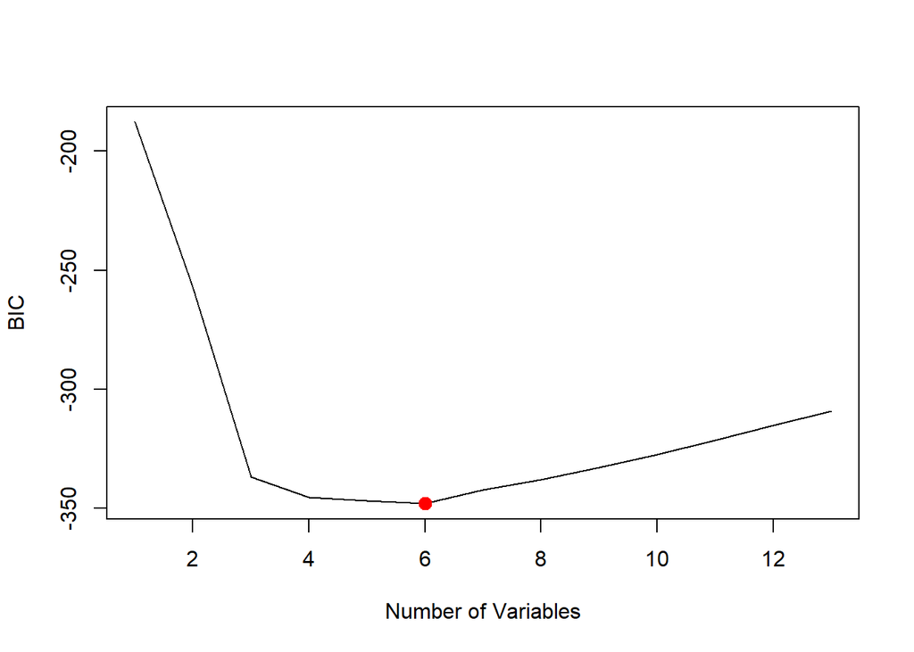

```r
fs = summary(forward_selection)
plot(fs$bic, xlab = "Number of Variables", ylab = "BIC", type = 'l')
l = which.min(fs$bic)
points(l, fs$bic[l], col = "red", cex = 2, pch = 20)
```

```r
coef(forward_selection, 5)
```

```
##     (Intercept) NBA_DraftNumber             Age              MP          `DRB%`
##      8.96878295     -0.11772131      0.61559299      0.00372382      0.10894767
##            VORP
##      0.79257168
```

```r
backward_selection = regsubsets(Salary ~ ., data = data, nvmax = 13, method = "forward")
summary(backward_selection)
```

```
## Subset selection object
## Call: regsubsets.formula(Salary ~ ., data = data, nvmax = 13, method = "forward")
## 16 Variables  (and intercept)
##                 Forced in Forced out
## NBA_DraftNumber     FALSE      FALSE
## Age                 FALSE      FALSE
## MP                  FALSE      FALSE
## PER                 FALSE      FALSE
## `TS%`               FALSE      FALSE
## `DRB%`              FALSE      FALSE
## VORP                FALSE      FALSE
## G                   FALSE      FALSE
## OBPM                FALSE      FALSE
## DBPM                FALSE      FALSE
## BPM                 FALSE      FALSE
## OWS                 FALSE      FALSE
## DWS                 FALSE      FALSE
## WS                  FALSE      FALSE
## `AST%`              FALSE      FALSE
## `STL%`              FALSE      FALSE
## 1 subsets of each size up to 13
## Selection Algorithm: forward
##           NBA_DraftNumber Age MP  PER `TS%` `DRB%` VORP G   OBPM DBPM BPM OWS
## 1  ( 1 )  " "             " " "*" " " " "   " "    " "  " " " "  " "  " " " "
## 2  ( 1 )  " "             "*" "*" " " " "   " "    " "  " " " "  " "  " " " "
## 3  ( 1 )  "*"             "*" "*" " " " "   " "    " "  " " " "  " "  " " " "
## 4  ( 1 )  "*"             "*" "*" " " " "   " "    "*"  " " " "  " "  " " " "
## 5  ( 1 )  "*"             "*" "*" " " " "   "*"    "*"  " " " "  " "  " " " "
## 6  ( 1 )  "*"             "*" "*" " " " "   "*"    "*"  "*" " "  " "  " " " "
## 7  ( 1 )  "*"             "*" "*" " " "*"   "*"    "*"  "*" " "  " "  " " " "
## 8  ( 1 )  "*"             "*" "*" "*" "*"   "*"    "*"  "*" " "  " "  " " " "
## 9  ( 1 )  "*"             "*" "*" "*" "*"   "*"    "*"  "*" " "  " "  "*" " "
## 10  ( 1 ) "*"             "*" "*" "*" "*"   "*"    "*"  "*" " "  " "  "*" "*"
## 11  ( 1 ) "*"             "*" "*" "*" "*"   "*"    "*"  "*" " "  " "  "*" "*"
## 12  ( 1 ) "*"             "*" "*" "*" "*"   "*"    "*"  "*" " "  " "  "*" "*"
## 13  ( 1 ) "*"             "*" "*" "*" "*"   "*"    "*"  "*" " "  " "  "*" "*"
##           DWS WS  `AST%` `STL%`
## 1  ( 1 )  " " " " " "    " "
## 2  ( 1 )  " " " " " "    " "
## 3  ( 1 )  " " " " " "    " "
## 4  ( 1 )  " " " " " "    " "
## 5  ( 1 )  " " " " " "    " "
## 6  ( 1 )  " " " " " "    " "
## 7  ( 1 )  " " " " " "    " "
## 8  ( 1 )  " " " " " "    " "
## 9  ( 1 )  " " " " " "    " "
## 10  ( 1 ) " " " " " "    " "
## 11  ( 1 ) " " " " "*"    " "
## 12  ( 1 ) "*" " " "*"    " "
## 13  ( 1 ) "*" "*" "*"    " "
```

```r
coef(backward_selection, 5)
```

```
##     (Intercept) NBA_DraftNumber             Age              MP          `DRB%`
##      8.96878295     -0.11772131      0.61559299      0.00372382      0.10894767
##            VORP
##      0.79257168
```

세 결과가 동일하지 않은 것을 확인할 수 있다. 결국에 경로가 있는 방법들은 최적의 회귀식을 언제나 찾아낼 수는 없다.

## 2. ridge regression

원래는 최적의 람다를 선택하는 과정이 들어가야하지만, 이를 위해서는 CV(Cross Validation)에 대한 이해가 필요하기 때문에, 람다 값이 변함에 따라 생기는 변화를 보려 한다.

```r
library(glmnet)
# if alpha=0 -> ridge; if alpha=1 -> lasso.
# Default: standardize = TRUE
```

ridge 가봅시다. 데이터를 x와 y를 나눠서 넣어줘야 하기 때문에 형태를 맞춰줍시다.

```r
data_x = model.matrix(Salary ~ ., data = data)[,-1]
data_y = data$Salary
```

```r
lm_fit1 = lm(Salary ~ ., data = data)
lm_fit1$coefficients
```

```
##     (Intercept) NBA_DraftNumber             Age              MP             PER
##     9.741940799    -0.116544058     0.605687132     0.005950999    -0.140100953
##           `TS%`          `DRB%`            VORP               G            OBPM
##     4.452624012     0.161144858     0.147025606    -0.080576747    -1.508160776
##            DBPM             BPM             OWS             DWS              WS
##    -1.521561670     1.671106101    -1.735601628    -2.084407677     1.960173777
##          `AST%`          `STL%`
##     0.017381794    -0.054440770
```

```r
ridge_fit1 = glmnet(x = data_x, y = data_y, alpha = 0, lambda = 0)
ridge_fit1$beta
```

```
## 16 x 1 sparse Matrix of class "dgCMatrix"
##                           s0
## NBA_DraftNumber -0.116759384
## Age              0.604320950
## MP               0.005928588
## PER             -0.142814203
## `TS%`            4.477880103
## `DRB%`           0.161992032
## VORP             0.154255863
## G               -0.080326429
## OBPM             0.157810326
## DBPM             0.134854982
## BPM              0.007885098
## OWS              0.166753192
## DWS             -0.188858762
## WS               0.064420907
## `AST%`           0.016295119
## `STL%`          -0.041866807
```

```r
ridge_fit2 = glmnet(x = data_x, y = data_y, alpha = 0, lambda = 1)
ridge_fit3 = glmnet(x = data_x, y = data_y, alpha = 0, lambda = 10)
ridge_fit4 = glmnet(x = data_x, y = data_y, alpha = 0, lambda = 1000)
ridge_fit5 = glmnet(x = data_x, y = data_y, alpha = 0, lambda = 10^7)

cbind(ridge_fit1$beta, ridge_fit2$beta, ridge_fit3$beta, ridge_fit4$beta, ridge_fit5$beta)
```

```
## 16 x 5 sparse Matrix of class "dgCMatrix"
##                           s0           s0            s0            s0
## NBA_DraftNumber -0.116759384 -0.107086626 -0.0565674531 -0.0014943674
## Age              0.604320950  0.535944912  0.2702645634  0.0054042926
## MP               0.005928588  0.002892939  0.0011458090  0.0000464028
## PER             -0.142814203 -0.048491471 -0.0004954853  0.0016293661
## `TS%`            4.477880103  1.654234152  0.7139205040  0.1132760592
## `DRB%`           0.161992032  0.094859719  0.0439834173  0.0020114079
## VORP             0.154255863  0.319014486  0.3596151654  0.0244499731
## G               -0.080326429 -0.009694633  0.0190780521  0.0011873599
## OBPM             0.157810326  0.026173509  0.0179606169  0.0030988654
## DBPM             0.134854982  0.018772726  0.0717958951  0.0067547829
## BPM              0.007885098  0.026565115  0.0283079957  0.0038262626
## OWS              0.166753192  0.208990787  0.2665489494  0.0168112228
## DWS             -0.188858762  0.392359933  0.5608129935  0.0329676047
## WS               0.064420907  0.174112449  0.2165610740  0.0132882595
## `AST%`           0.016295119  0.024096799  0.0272215825  0.0015837897
## `STL%`          -0.041866807 -0.074461364 -0.0905518833  0.0013235336
##                            s0
## NBA_DraftNumber -1.539004e-07
## Age              5.484281e-07
## MP               4.846467e-09
## PER              1.762207e-07
## `TS%`            1.218679e-05
## `DRB%`           2.107816e-07
## VORP             2.577621e-06
## G                1.246363e-07
## OBPM             3.332302e-07
## DBPM             7.148078e-07
## BPM              4.092589e-07
## OWS              1.769343e-06
## DWS              3.463773e-06
## WS               1.397640e-06
## `AST%`           1.665417e-07
## `STL%`           1.583206e-07
```

## 3. Lasso regression

```r
lasso_fit1 = glmnet(x = data_x, y = data_y, alpha = 1, lambda = 0.001)
lasso_fit2 = glmnet(x = data_x, y = data_y, alpha = 1, lambda = 0.01)
lasso_fit3 = glmnet(x = data_x, y = data_y, alpha = 1, lambda = 0.1)
lasso_fit4 = glmnet(x = data_x, y = data_y, alpha = 1, lambda = 1)
lasso_fit5 = glmnet(x = data_x, y = data_y, alpha = 1, lambda = 10)

cbind(lasso_fit1$beta, lasso_fit2$beta, lasso_fit3$beta, lasso_fit4$beta, lasso_fit5$beta)
```

```
## 16 x 5 sparse Matrix of class "dgCMatrix"
##                           s0           s0           s0           s0 s0
## NBA_DraftNumber -0.116743364 -0.116335123 -0.113930750 -0.086942659  0
## Age              0.604341079  0.604095250  0.592730953  0.377892618  .
## MP               0.005901449  0.005742049  0.004370022  0.002647731  .
## PER             -0.139832958 -0.118079251  .            .            .
## `TS%`            4.436709730  4.076239359  0.223414268  .            .
## `DRB%`           0.160768562  0.151150604  0.106321794  .            .
## VORP             0.159968987  0.161095307  0.538869828  .            .
## G               -0.079474383 -0.074915748 -0.024469322  .            .
## OBPM             0.152640746  .            .            .            .
## DBPM             0.131758284  .            0.005203738  .            .
## BPM              0.008649396  0.130006254  .            .            .
## OWS              0.183529242  0.228557461  0.100839837  .            .
## DWS             -0.163760191 -0.051062409  .            .            .
## WS               0.045407815  .            .            0.413677182  .
## `AST%`           0.016078636  0.014548784  .            .            .
## `STL%`          -0.040561342 -0.034582351  .            .            .
```

점점 람다가 커짐에 따라 확실히 0을 찍는 변수들이 존재한다. 변수선택의 효과가 생기는 것.